# AIPND Capstone

> **提示**：
> 1. 欢迎来到**Python 人工智能入门**毕业项目！引用段会添加这类提示，来帮助你理清整个项目的思路。在你提交项目之前，你可以浏览一下报告，将这一段删除，以保持报告的简洁性。首先，你需要双击该 Markdown 框(cell)，将标题更改为与数据集和调查相关的标题。
> 2. 在这个项目模板中，会在具体内容后的小括号 *()* 中或其他地方添加一部分提示，请在最终项目提交前，删除括号及里面的提示，保持报告的整洁。
> 3. 请先通读整个文档，理清思路后再着手解答
> 4. Have fun!

# Python 人工智能入门 毕业项目

# 利用机器学习模型预测股票走势

## 2020年1月30日

## 目录

- 定义
- 分析
- 实现
- 结果
- 结论

## Ⅰ.定义

在第一节中，你需要对你选定的问题作出定义

### 1.项目概况

在这个部分，你需要用浅显简洁的语句描述这个项目的一个总体概况。以下几个问题可以帮助你理清思路：

- *项目的背景信息是什么？*
- *做这个项目的出发点？*
- *数据集的大概情况是什么？*

### 2.问题陈述

在这个部分，你需要清楚地为你将要解决的问题下定义，这应该包括你解决问题将要使用的策略（任务的大纲）。你同时要详尽地讨论你期望的结果是怎样的。有几个问题是需要考虑的：

- *你是否清楚地定义了这个问题。站在读者的角度，他们能否明白你将要解决的问题是什么。*
- *你是否详尽地阐述了你将会如何解决这个问题？*
- *你期望什么样的结果，读者能明白你期望的这个结果吗？*

### 3.评价指标

在这里，你需要说明你将要用于评价自己的模型和结果的**指标**和**计算方法**。它们需要契合你所选问题的特点及其所在的领域，同时，你要保证他们的合理性。需要考虑的问题：

- *你是否清晰地定义了你所使用的指标和计算方法？*
- *你是否论述了这些指标和计算方法的合理性？*

- 通过收集 2010 - 2020 总共 10 年的沪深大盘指数的历史数据进行分析，对现实生活中的真实数据实践简单的机器学习的模型算法，并对来年的大盘指数涨跌做出预测
- 数据集包含从 2010-1-1 至 2020-1-1 的沪深指数。包含的字段是日期、收盘指数、当日最高指数、当日最低指数、交易量、涨跌（当日收盘指数 - 前一日收盘指数）、涨跌幅（涨跌 / 前一日收盘指数）
- 希望可以根据已知的大盘数据预计未来的大盘收盘指数，算出上一周的收盘指数、当日最高指数、当日最低指数、交易量、涨跌等的平均值，并结合月份、季度等特征预测未来的指数，使用多元线性回归，来预测未来的指数

## Ⅱ.分析

在第二节，你将对数据进行分析与整理，来进一步认识数据。

### 1.数据的探索

在这一部分，你需要探索你将要使用的数据。数据可以是若干个数据集，或者输入数据/文件，甚至可以是一个设定环境。不过在本项目中，我们已经给出了数据集，因此，你需要详尽地描述数据的类型。如果可以的话，你需要展示数据的一些统计量和基本信息（例如输入的特征（features)，输入里与定义相关的特性）。你还要说明数据中的任何需要被关注的异常或有趣的性质（例如需要做变换的特征，离群值等等）。你需要考虑：

- *如果你使用了数据集，你要详尽地讨论了你所使用数据集的某些特征，并且为阅读者呈现一个直观的样本*
- *如果你使用了数据集，你要计算并描述了它们的统计量，并对其中与你问题相关的地方进行讨论*
- *数据集或输入中是否存在异常、缺陷或其他特性？你为什么认为他们是异常？给出佐证你观点的理由(例如分类变量的处理，缺失数据，离群值等）*

### 2.探索性可视化

在这一部分，你需要对数据的特征或特性进行概括性或提取性的可视化。这个可视化的过程应该要适应你所使用的数据。就你为何使用这个形式的可视化，以及这个可视化过程为什么是有意义的，进行一定的讨论。你需要考虑的问题：

- *你是否对数据中与问题有关的特性进行了可视化？*
- *你对可视化结果进行详尽的分析和讨论了吗？*
- *绘图的坐标轴，标题，基准面是不是清晰定义了？*

### 3.算法和技术

在这一部分，你需要讨论你解决问题时用到的算法和技术。你需要根据问题的特性和所属领域来论述使用这些方法的合理性。你需要考虑：

- *你所使用的算法，包括用到的变量/参数都清晰地说明了吗？*
- *你是否已经详尽地描述并讨论了使用这些技术的合理性？*

> **提示**：*不应* 在每个 notebook 框 (cell) 中进行太多操作。可以自由创建框，来进行数据探索。在这个项目中，可以在初始 notebook 中进行大量探索性操作。不要求对其进行组织，但请务必仔细阅读备注，理解每个代码框的用途。完成分析之后，你可以创建 notebook 副本，在其中去除多余数据，组织好你的每一步分析，从而形成信息连贯、结构紧密的报告。

```python
import numpy as np
import pandas as pd
import matplotlib.pyplot as plt
import seaborn as sns

%matplotlib inline
```

```python
df = pd.read_csv('data.csv')
df.head()
```

|  | tradeDate | closeIndex | highestIndex | lowestIndex | turnoverVol | CHG | CHGPct |
| --- | --- | --- | --- | --- | --- | --- | --- |
| 0 | 2010-01-04 | 3535.23 | 3597.75 | 3535.23 | 6610108000 | -40.45 | -0.011313 |
| 1 | 2010-01-05 | 3564.04 | 3577.53 | 3497.66 | 8580964100 | 28.81 | 0.008149 |
| 2 | 2010-01-06 | 3541.73 | 3588.83 | 3541.17 | 7847312500 | -22.31 | -0.006260 |
| 3 | 2010-01-07 | 3471.46 | 3558.56 | 3452.77 | 8035003700 | -70.27 | -0.019841 |
| 4 | 2010-01-08 | 3480.13 | 3482.08 | 3426.70 | 6079025300 | 8.67 | 0.002498 |

```python
df.info()
```

```
<class 'pandas.core.frame.DataFrame'>
RangeIndex: 2431 entries, 0 to 2430
Data columns (total 7 columns):
tradeDate       2431 non-null object
closeIndex      2431 non-null float64
highestIndex    2431 non-null float64
lowestIndex     2431 non-null float64
turnoverVol     2431 non-null int64
CHG             2431 non-null float64
CHGPct          2431 non-null float64
dtypes: float64(5), int64(1), object(1)
memory usage: 133.0+ KB
```

- 数据集总共有 2431 条数据，并且所有列都没有缺失值
- tradeDate字段是 object 类型，需要将它转成日期类型，以便拆分出年月日，具体某一天等信息

```python
df.describe()
```

|  | closeIndex | highestIndex | lowestIndex | turnoverVol | CHG | CHGPct |
| --- | --- | --- | --- | --- | --- | --- |
| count | 2431.000000 | 2431.000000 | 2431.000000 | 2.431000e+03 | 2431.000000 | 2431.000000 |
| mean | 3145.792846 | 3170.504102 | 3116.682684 | 1.084057e+10 | 0.214275 | 0.000163 |
| std | 635.259252 | 641.240070 | 626.643946 | 9.043278e+09 | 49.103763 | 0.014567 |
| min | 2086.970000 | 2118.790000 | 2023.170000 | 2.190125e+09 | -370.321000 | -0.087477 |
| 25% | 2561.495000 | 2582.780000 | 2540.610000 | 5.801616e+09 | -19.535000 | -0.006445 |
| 50% | 3200.340000 | 3225.418000 | 3166.770000 | 8.205615e+09 | 0.772300 | 0.000247 |
| 75% | 3599.083350 | 3634.990450 | 3566.422000 | 1.191077e+10 | 21.820000 | 0.007009 |
| max | 5353.750000 | 5380.430000 | 5283.090000 | 6.864391e+10 | 281.449400 | 0.067147 |

```python
print((df['CHG'] > 0).mean())
print((df['CHG'] <= 0).mean())
```

```
0.5109008638420404
0.4890991361579597
```

- 10 年间，指数上涨的比率为 51%，下跌或不涨的比率为 49%，基本相等，上涨的比率略高

```python
df['tradeDate'] = pd.to_datetime(df['tradeDate'])
df['tradeYear'] = df['tradeDate'].apply(lambda x : x.year)
df['tradeMonth'] = df['tradeDate'].apply(lambda x : x.month)
df['tradeDay'] = df['tradeDate'].apply(lambda x : x.day_name())
df['tradeWeek'] = df['tradeDate'].apply(lambda x : f"week {str(x.week)}")
```

```python
df.info()
```

```
<class 'pandas.core.frame.DataFrame'>
RangeIndex: 2431 entries, 0 to 2430
Data columns (total 11 columns):
tradeDate       2431 non-null datetime64[ns]
closeIndex      2431 non-null float64
highestIndex    2431 non-null float64
lowestIndex     2431 non-null float64
turnoverVol     2431 non-null int64
CHG             2431 non-null float64
CHGPct          2431 non-null float64
tradeYear       2431 non-null int64
tradeMonth      2431 non-null int64
tradeDay        2431 non-null object
tradeWeek       2431 non-null object
dtypes: datetime64[ns](1), float64(5), int64(3), object(2)
memory usage: 209.0+ KB
```

```python
df.head()
```

|  | tradeDate | closeIndex | highestIndex | lowestIndex | turnoverVol | CHG | CHGPct | tradeYear | tradeMonth | tradeDay | tradeWeek |
| --- | --- | --- | --- | --- | --- | --- | --- | --- | --- | --- | --- |
| 0 | 2010-01-04 | 3535.23 | 3597.75 | 3535.23 | 6610108000 | -40.45 | -0.011313 | 2010 | 1 | Monday | week 1 |
| 1 | 2010-01-05 | 3564.04 | 3577.53 | 3497.66 | 8580964100 | 28.81 | 0.008149 | 2010 | 1 | Tuesday | week 1 |
| 2 | 2010-01-06 | 3541.73 | 3588.83 | 3541.17 | 7847312500 | -22.31 | -0.006260 | 2010 | 1 | Wednesday | week 1 |
| 3 | 2010-01-07 | 3471.46 | 3558.56 | 3452.77 | 8035003700 | -70.27 | -0.019841 | 2010 | 1 | Thursday | week 1 |
| 4 | 2010-01-08 | 3480.13 | 3482.08 | 3426.70 | 6079025300 | 8.67 | 0.002498 | 2010 | 1 | Friday | week 1 |

- 将 tradeDate 列转换为事件类型，并将它拆分出年、月、日、周。

```python
# 找出 10 年中，涨跌幅最小的值，以及它们对应的日期
df.groupby(['tradeYear'])[['tradeDate', 'CHGPct']].min()
```

| tradeYear | tradeDate | CHGPct |
| --- | --- | --- |
| 2010 | 2010-01-04 | -0.062151 |
| 2011 | 2011-01-04 | -0.038006 |
| 2012 | 2012-01-04 | -0.028361 |
| 2013 | 2013-01-04 | -0.063080 |
| 2014 | 2014-01-02 | -0.044874 |
| 2015 | 2015-01-05 | -0.087477 |
| 2016 | 2016-01-04 | -0.070206 |
| 2017 | 2017-01-03 | -0.029608 |
| 2018 | 2018-01-02 | -0.047990 |
| 2019 | 2019-01-02 | -0.058416 |

```python
# 找出 10 年中，涨跌幅最大的值，以及它们对应的日期
df.groupby(['tradeYear'])[['tradeDate', 'CHGPct']].max()
```

| tradeYear | tradeDate | CHGPct |
| --- | --- | --- |
| 2010 | 2010-12-31 | 0.037807 |
| 2011 | 2011-12-30 | 0.036352 |
| 2012 | 2012-12-31 | 0.050490 |
| 2013 | 2013-12-31 | 0.046141 |
| 2014 | 2014-12-31 | 0.046099 |
| 2015 | 2015-12-31 | 0.067147 |
| 2016 | 2016-12-30 | 0.041164 |
| 2017 | 2017-12-29 | 0.017958 |
| 2018 | 2018-12-28 | 0.043167 |
| 2019 | 2019-12-31 | 0.059477 |

```python
# 找出 10 年中，收盘指数最小的值，以及它们对应的日期
df.groupby(['tradeYear'])[['tradeDate', 'closeIndex']].min()
```

| tradeYear | tradeDate | closeIndex |
| --- | --- | --- |
| 2010 | 2010-01-04 | 2512.6500 |
| 2011 | 2011-01-04 | 2305.0300 |
| 2012 | 2012-01-04 | 2108.8500 |
| 2013 | 2013-01-04 | 2160.7400 |
| 2014 | 2014-01-02 | 2086.9700 |
| 2015 | 2015-01-05 | 3025.6920 |
| 2016 | 2016-01-04 | 2853.7562 |
| 2017 | 2017-01-03 | 3317.6241 |
| 2018 | 2018-01-02 | 2990.5057 |
| 2019 | 2019-01-02 | 2964.8421 |

```python
# 找出 10 年中，收盘指数最大的值，以及它们对应的日期
df.groupby(['tradeYear'])[['tradeDate', 'closeIndex']].max()
```

| tradeYear | tradeDate | closeIndex |
| --- | --- | --- |
| 2010 | 2010-12-31 | 3564.0400 |
| 2011 | 2011-12-30 | 3372.0300 |
| 2012 | 2012-12-31 | 2717.7800 |
| 2013 | 2013-12-31 | 2775.8400 |
| 2014 | 2014-12-31 | 3533.7100 |
| 2015 | 2015-12-31 | 5353.7500 |
| 2016 | 2016-12-30 | 3565.0360 |
| 2017 | 2017-12-29 | 4227.5666 |
| 2018 | 2018-12-28 | 4389.8853 |
| 2019 | 2019-12-31 | 4120.6078 |

```python
df.groupby(['tradeYear'])['CHGPct'].std().sort_values()
```

```
tradeYear
2017    0.006392
2014    0.012129
2019    0.012507
2012    0.012874
2011    0.013017
2018    0.013496
2013    0.013997
2016    0.014000
2010    0.015834
2015    0.024836
Name: CHGPct, dtype: float64
```

- 通过计算涨跌幅的标准差排序后，发现 2015 年涨跌的浮动比较大，股市比较动荡，2017 年涨跌浮动最小，股市最稳定

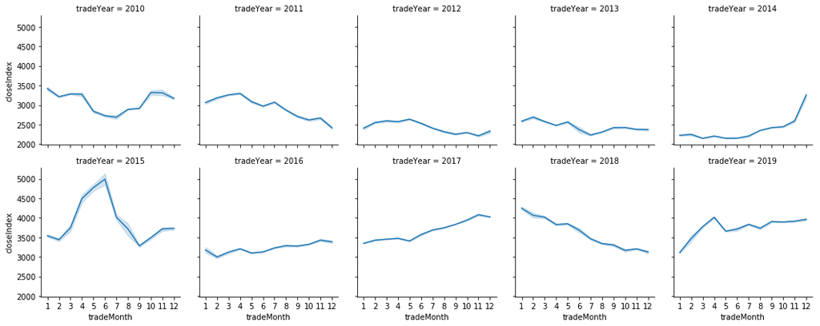

```python
g = sns.FacetGrid(data = df, col = 'tradeYear', col_wrap = 5)
g.map(sns.lineplot, 'tradeMonth', 'closeIndex');
g.set(xticks = list(df['tradeMonth'].unique()));
```

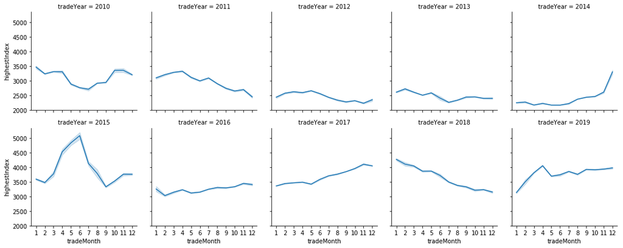

```python
g = sns.FacetGrid(data = df, col = 'tradeYear', col_wrap = 5)
g.map(sns.lineplot, 'tradeMonth', 'highestIndex');
g.set(xticks = list(df['tradeMonth'].unique()));
```

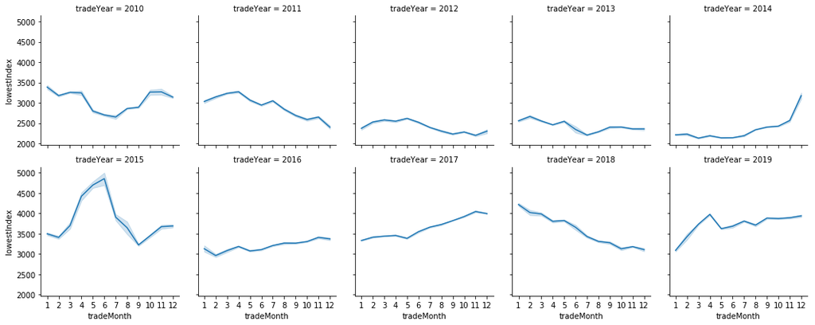

```python
g = sns.FacetGrid(data = df, col = 'tradeYear', col_wrap = 5)
g.map(sns.lineplot, 'tradeMonth', 'lowestIndex');
g.set(xticks = list(df['tradeMonth'].unique()));
```

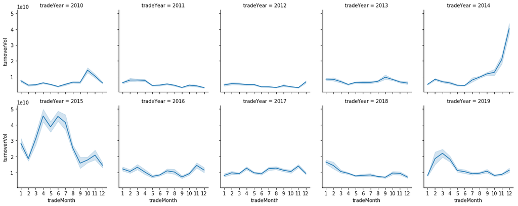

```python
g = sns.FacetGrid(data = df, col = 'tradeYear', col_wrap = 5)
g.map(sns.lineplot, 'tradeMonth', 'turnoverVol');
g.set(xticks = list(df['tradeMonth'].unique()));
```

- 交易量的趋势和收盘指数几乎差不多

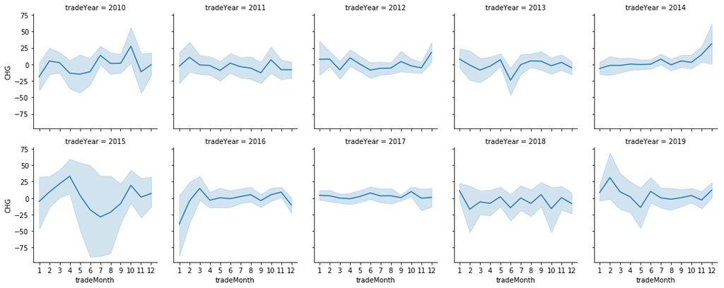

```python
g = sns.FacetGrid(data = df, col = 'tradeYear', col_wrap = 5)
g.map(sns.lineplot, 'tradeMonth', 'CHG');
g.set(xticks = list(df['tradeMonth'].unique()));
```

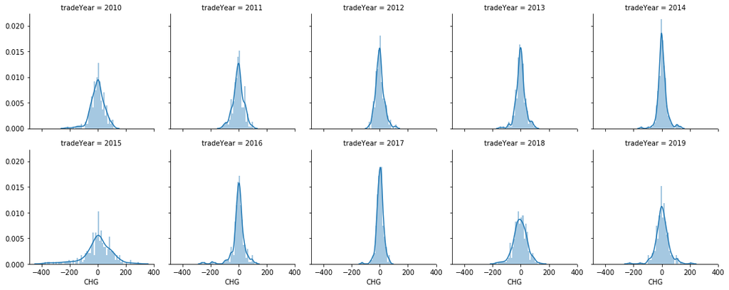

```python
bins = np.arange(-400, 300, 10)
g = sns.FacetGrid(data = df, col = 'tradeYear', col_wrap = 5)
g.map(sns.distplot, 'CHG', bins = bins);
```

- 涨跌分布基本为正态分布，分布的宽度和上面计算的标准差是一致的，2015 年分布最宽，2017 年分布最窄

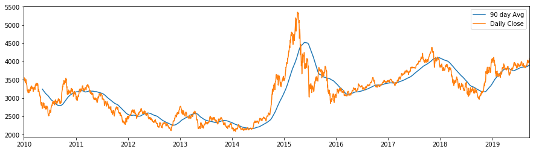

```python
# 10 年的收盘指数和 90 天收盘指数平均值对比趋势图
plt.figure(figsize = (15, 4))
df['closeIndex'].rolling(window = 90).mean().plot(label = '90 day Avg')
df['closeIndex'].plot(label = 'Daily Close');
plt.xticks(np.arange(0, 2500, 250), df['tradeYear'].unique());
plt.legend();
```

[figure not shown]

```python
# 10 年的交易量和 90 天交易量平均值对比趋势图
plt.figure(figsize = (15, 4))
df['turnoverVol'].rolling(window = 90).mean().plot(label = '30 day Avg')
df['turnoverVol'].plot(label = 'Daily Close');
plt.xticks(np.arange(0, 2500, 250), df['tradeYear'].unique());
plt.legend();
```

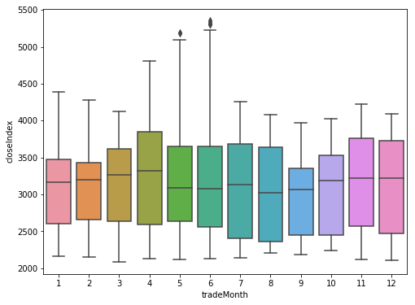

```python
plt.figure(figsize = (8, 6))
sns.boxplot(x = 'tradeMonth', y = 'closeIndex', data = df);
```

- 10 年中的各个月份的收盘指数中，5，6 月的收盘指数的范围最大，包含若干异常值

## Ⅲ. 实现

在第三节中，你需要引入自己选定的模型，并使用数据集中的数据去训练兵优化它，使得最终的模型能够得到想要的结果

### 1.数据预处理

在这一部分， 你需要清晰记录你所有必要的数据预处理步骤。在前一个部分所描述的数据的异常或特性在这一部分需要被更正和处理。需要考虑的问题有：

- *如果你选择的算法需要进行特征选取或特征变换，你对此进行记录和描述了吗？*
- **数据的探索**这一部分中提及的异常和特性是否被更正了，对此进行记录和描述了吗？
- *如果你认为不需要进行预处理，你解释个中原因了吗？*

### 2.执行过程

在这一部分， 你需要描述你所建立的模型在给定数据上执行过程。模型的执行过程，以及过程中遇到的困难的描述应该清晰明了地记录和描述。需要考虑的问题：

- *你所用到的算法和技术执行的方式是否清晰记录了？*
- *在运用上面所提及的技术及指标的执行过程中是否遇到了困难，是否需要作出改动来得到想要的结果？*

### 3.完善

在这一部分，你需要描述你对原有的算法和技术完善的过程。例如调整模型的参数以达到更好的结果的过程应该有所记录。你需要记录最初和最终的模型，以及过程中有代表性意义的结果。你需要考虑的问题：

- *初始结果是否清晰记录了？*
- *完善的过程是否清晰记录了，其中使用了什么技术？*
- *完善过程中的结果以及最终结果是否清晰记录了？*

```python
month_dict = {1 : 'Jan', 2 : 'Feb', 3 : 'Mar', 4 : 'Apr', 5 : 'May', 6 : 'Jun', 7 : 'Jul', 8 : 'Aug', 9 : 'Sep', 10 : 'Oct', 11 : 'Nov', 12 : 'Dec'}
```

```python
def get_qtr(mon):
    if mon <= 3:
        return 'Q1'
    elif mon > 3 and mon <= 6:
        return 'Q2'
    elif mon > 6 and mon <= 9:
        return 'Q3'
    else:
        return 'Q4'
```

```python
# 添加月份名称列和季度列
df['tradeMonthName'] = df['tradeMonth'].apply(lambda x : month_dict[x])
df['tradeQtr'] = df['tradeMonth'].apply(lambda x : get_qtr(x))
```

```python
# 将月份和季度转为虚拟变量
df2 = df.join(pd.get_dummies(df['tradeMonthName']))
df2 = df2.join(pd.get_dummies(df['tradeQtr']))
df2.head()
```

|  | tradeDate | closeIndex | highestIndex | lowestIndex | turnoverVol | CHG | CHGPct | tradeYear | tradeMonth | tradeDay | ... | Jun | Mar | May | Nov | Oct | Sep | Q1 | Q2 | Q3 | Q4 |
| --- | --- | --- | --- | --- | --- | --- | --- | --- | --- | --- | --- | --- | --- | --- | --- | --- | --- | --- | --- | --- | --- |
| 0 | 2010-01-04 | 3535.23 | 3597.75 | 3535.23 | 6610108000 | -40.45 | -0.011313 | 2010 | 1 | Monday | ... | 0 | 0 | 0 | 0 | 0 | 0 | 1 | 0 | 0 | 0 |
| 1 | 2010-01-05 | 3564.04 | 3577.53 | 3497.66 | 8580964100 | 28.81 | 0.008149 | 2010 | 1 | Tuesday | ... | 0 | 0 | 0 | 0 | 0 | 0 | 1 | 0 | 0 | 0 |
| 2 | 2010-01-06 | 3541.73 | 3588.83 | 3541.17 | 7847312500 | -22.31 | -0.006260 | 2010 | 1 | Wednesday | ... | 0 | 0 | 0 | 0 | 0 | 0 | 1 | 0 | 0 | 0 |
| 3 | 2010-01-07 | 3471.46 | 3558.56 | 3452.77 | 8035003700 | -70.27 | -0.019841 | 2010 | 1 | Thursday | ... | 0 | 0 | 0 | 0 | 0 | 0 | 1 | 0 | 0 | 0 |
| 4 | 2010-01-08 | 3480.13 | 3482.08 | 3426.70 | 6079025300 | 8.67 | 0.002498 | 2010 | 1 | Friday | ... | 0 | 0 | 0 | 0 | 0 | 0 | 1 | 0 | 0 | 0 |

5 rows × 29 columns

```python
# 计算高低指数占百分比
df_tmp = pd.DataFrame()
df_tmp['HLPct'] = (df2['highestIndex'] - df2['lowestIndex']) / df2['closeIndex'] * 100
```

```python
# 将 df_tmp 的索引值 +1，并和 df 关联后，可以为当日得到前一日的高低指数占百分比
df_tmp.reset_index(inplace = True)
df_tmp['index'] = df_tmp['index'] + 1
df_tmp.set_index('index', inplace = True)
```

```python
df2 = df2.join(df_tmp)
```

```python
# 使用平均值填补空值
df2['HLPct'] = df2['HLPct'].fillna(df2['HLPct'].mean())
```

```python
df2.head()
```

|  | tradeDate | closeIndex | highestIndex | lowestIndex | turnoverVol | CHG | CHGPct | tradeYear | tradeMonth | tradeDay | ... | Mar | May | Nov | Oct | Sep | Q1 | Q2 | Q3 | Q4 | HLPct |
| --- | --- | --- | --- | --- | --- | --- | --- | --- | --- | --- | --- | --- | --- | --- | --- | --- | --- | --- | --- | --- | --- |
| 0 | 2010-01-04 | 3535.23 | 3597.75 | 3535.23 | 6610108000 | -40.45 | -0.011313 | 2010 | 1 | Monday | ... | 0 | 0 | 0 | 0 | 0 | 1 | 0 | 0 | 0 | 1.693023 |
| 1 | 2010-01-05 | 3564.04 | 3577.53 | 3497.66 | 8580964100 | 28.81 | 0.008149 | 2010 | 1 | Tuesday | ... | 0 | 0 | 0 | 0 | 0 | 1 | 0 | 0 | 0 | 1.768485 |
| 2 | 2010-01-06 | 3541.73 | 3588.83 | 3541.17 | 7847312500 | -22.31 | -0.006260 | 2010 | 1 | Wednesday | ... | 0 | 0 | 0 | 0 | 0 | 1 | 0 | 0 | 0 | 2.240996 |
| 3 | 2010-01-07 | 3471.46 | 3558.56 | 3452.77 | 8035003700 | -70.27 | -0.019841 | 2010 | 1 | Thursday | ... | 0 | 0 | 0 | 0 | 0 | 1 | 0 | 0 | 0 | 1.345670 |
| 4 | 2010-01-08 | 3480.13 | 3482.08 | 3426.70 | 6079025300 | 8.67 | 0.002498 | 2010 | 1 | Friday | ... | 0 | 0 | 0 | 0 | 0 | 1 | 0 | 0 | 0 | 3.047421 |

5 rows × 30 columns

```python
# 计算每一周的收盘、高低指数、交易量、涨幅等的平均值
ci_week = df2.groupby(['tradeYear', 'tradeWeek'])[['closeIndex', 'highestIndex', 'lowestIndex', 'turnoverVol', 'CHG', 'CHGPct']].mean()
ci_week.columns = ['last_week_ci', 'last_week_hi', 'last_week_li', 'last_week_vol', 'last_week_chg', 'last_week_chgpct']
ci_week.head()
```

| tradeYear | tradeWeek | last_week_ci | last_week_hi | last_week_li | last_week_vol | last_week_chg | last_week_chgpct |
| --- | --- | --- | --- | --- | --- | --- | --- |
| 2010 | week 1 | 3518.518 | 3560.950 | 3490.706 | 7.430483e+09 | -19.110 | -0.005353 |
|  | week 10 | 3276.314 | 3305.054 | 3253.118 | 4.592131e+09 | -5.326 | -0.001606 |
|  | week 11 | 3244.500 | 3260.978 | 3211.180 | 4.150064e+09 | 12.148 | 0.003805 |
|  | week 12 | 3271.800 | 3295.472 | 3255.174 | 4.659124e+09 | -3.774 | -0.001100 |
|  | week 13 | 3374.030 | 3382.092 | 3344.884 | 6.622646e+09 | 26.470 | 0.008013 |

```python
# 新建 df_tmp2，获得 df2 的 tradeYear，tradeWeek 列
df_tmp2 = df2[['tradeYear', 'tradeWeek']]
```

```python
# 将 df_tmp2 和 ci_week 关联，让每一天都获得每一周的收盘、高低指数、交易量、涨幅等的平均值
df_tmp2 = df_tmp2.set_index(['tradeYear', 'tradeWeek']).join(ci_week)
```

```python
df_tmp2 = df_tmp2.reset_index().reset_index()
```

```python
# 将索引值 +5
df_tmp2['index'] = df_tmp2['index'] + 5
```

```python
df_tmp2.set_index('index', inplace = True)
df_tmp2.drop(['tradeYear', 'tradeWeek'], axis = 1, inplace = True)
df_tmp2.head()
```

| index | last_week_ci | last_week_hi | last_week_li | last_week_vol | last_week_chg | last_week_chgpct |
| --- | --- | --- | --- | --- | --- | --- |
| 5 | 3518.518 | 3560.95 | 3490.706 | 7.430483e+09 | -19.11 | -0.005353 |
| 6 | 3518.518 | 3560.95 | 3490.706 | 7.430483e+09 | -19.11 | -0.005353 |
| 7 | 3518.518 | 3560.95 | 3490.706 | 7.430483e+09 | -19.11 | -0.005353 |
| 8 | 3518.518 | 3560.95 | 3490.706 | 7.430483e+09 | -19.11 | -0.005353 |
| 9 | 3518.518 | 3560.95 | 3490.706 | 7.430483e+09 | -19.11 | -0.005353 |

```python
# df2 和 df_tmp2 关联后，每一天都会得到上一周的收盘、高低指数、交易量、涨幅等的平均值
df2 = df2.join(df_tmp2)
```

```python
# 循环将新添加的每一列的空值填补为这一列的平均值
for col in ci_week.columns:
    df2[col] = df2[col].fillna(df2[col].mean())
```

```python
df2.head(10)
```

|  | tradeDate | closeIndex | highestIndex | lowestIndex | turnoverVol | CHG | CHGPct | tradeYear | tradeMonth | tradeDay | ... | Q2 | Q3 | Q4 | HLPct | last_week_ci | last_week_hi | last_week_li | last_week_vol | last_week_chg | last_week_chgpct |
| --- | --- | --- | --- | --- | --- | --- | --- | --- | --- | --- | --- | --- | --- | --- | --- | --- | --- | --- | --- | --- | --- |
| 0 | 2010-01-04 | 3535.23 | 3597.75 | 3535.23 | 6610108000 | -40.45 | -0.011313 | 2010 | 1 | Monday | ... | 0 | 0 | 0 | 1.693023 | 3144.645819 | 3169.340917 | 3115.599544 | 1.080618e+10 | 0.120077 | 0.000136 |
| 1 | 2010-01-05 | 3564.04 | 3577.53 | 3497.66 | 8580964100 | 28.81 | 0.008149 | 2010 | 1 | Tuesday | ... | 0 | 0 | 0 | 1.768485 | 3144.645819 | 3169.340917 | 3115.599544 | 1.080618e+10 | 0.120077 | 0.000136 |
| 2 | 2010-01-06 | 3541.73 | 3588.83 | 3541.17 | 7847312500 | -22.31 | -0.006260 | 2010 | 1 | Wednesday | ... | 0 | 0 | 0 | 2.240996 | 3144.645819 | 3169.340917 | 3115.599544 | 1.080618e+10 | 0.120077 | 0.000136 |
| 3 | 2010-01-07 | 3471.46 | 3558.56 | 3452.77 | 8035003700 | -70.27 | -0.019841 | 2010 | 1 | Thursday | ... | 0 | 0 | 0 | 1.345670 | 3144.645819 | 3169.340917 | 3115.599544 | 1.080618e+10 | 0.120077 | 0.000136 |
| 4 | 2010-01-08 | 3480.13 | 3482.08 | 3426.70 | 6079025300 | 8.67 | 0.002498 | 2010 | 1 | Friday | ... | 0 | 0 | 0 | 3.047421 | 3144.645819 | 3169.340917 | 3115.599544 | 1.080618e+10 | 0.120077 | 0.000136 |
| 5 | 2010-01-11 | 3482.05 | 3594.53 | 3465.32 | 8998017200 | 1.92 | 0.000552 | 2010 | 1 | Monday | ... | 0 | 0 | 0 | 1.591320 | 3518.518000 | 3560.950000 | 3490.706000 | 7.430483e+09 | -19.110000 | -0.005353 |
| 6 | 2010-01-12 | 3534.92 | 3535.41 | 3437.66 | 9374327800 | 52.87 | 0.015184 | 2010 | 1 | Tuesday | ... | 0 | 0 | 0 | 3.710745 | 3518.518000 | 3560.950000 | 3490.706000 | 7.430483e+09 | -19.110000 | -0.005353 |
| 7 | 2010-01-13 | 3421.14 | 3490.11 | 3415.69 | 11245790100 | -113.78 | -0.032187 | 2010 | 1 | Wednesday | ... | 0 | 0 | 0 | 2.765268 | 3518.518000 | 3560.950000 | 3490.706000 | 7.430483e+09 | -19.110000 | -0.005353 |
| 8 | 2010-01-14 | 3469.05 | 3470.32 | 3411.81 | 8335325200 | 47.91 | 0.014004 | 2010 | 1 | Thursday | ... | 0 | 0 | 0 | 2.175298 | 3518.518000 | 3560.950000 | 3490.706000 | 7.430483e+09 | -19.110000 | -0.005353 |
| 9 | 2010-01-15 | 3482.74 | 3500.07 | 3448.66 | 7254310200 | 13.69 | 0.003946 | 2010 | 1 | Friday | ... | 0 | 0 | 0 | 1.686629 | 3518.518000 | 3560.950000 | 3490.706000 | 7.430483e+09 | -19.110000 | -0.005353 |

10 rows × 36 columns

```python
from sklearn.linear_model import LinearRegression
from sklearn.model_selection import train_test_split
import statsmodels.api as sms
```

```python
# 将 df2 中的非特征列删除，并保存到 df3 中
df3 = df2.drop(['tradeDate', 'highestIndex', 'lowestIndex', 'turnoverVol', 'CHG', 'CHGPct', 'tradeYear', 'tradeMonth', 'tradeDay', 'tradeWeek','tradeMonthName', 'tradeQtr', 'Jan', 'Q1'], axis = 1)
```

```python
df3.head()
```

|  | closeIndex | Apr | Aug | Dec | Feb | Jul | Jun | Mar | May | Nov | ... | Q2 | Q3 | Q4 | HLPct | last_week_ci | last_week_hi | last_week_li | last_week_vol | last_week_chg | last_week_chgpct |
| --- | --- | --- | --- | --- | --- | --- | --- | --- | --- | --- | --- | --- | --- | --- | --- | --- | --- | --- | --- | --- | --- |
| 0 | 3535.23 | 0 | 0 | 0 | 0 | 0 | 0 | 0 | 0 | 0 | ... | 0 | 0 | 0 | 1.693023 | 3144.645819 | 3169.340917 | 3115.599544 | 1.080618e+10 | 0.120077 | 0.000136 |
| 1 | 3564.04 | 0 | 0 | 0 | 0 | 0 | 0 | 0 | 0 | 0 | ... | 0 | 0 | 0 | 1.768485 | 3144.645819 | 3169.340917 | 3115.599544 | 1.080618e+10 | 0.120077 | 0.000136 |
| 2 | 3541.73 | 0 | 0 | 0 | 0 | 0 | 0 | 0 | 0 | 0 | ... | 0 | 0 | 0 | 2.240996 | 3144.645819 | 3169.340917 | 3115.599544 | 1.080618e+10 | 0.120077 | 0.000136 |
| 3 | 3471.46 | 0 | 0 | 0 | 0 | 0 | 0 | 0 | 0 | 0 | ... | 0 | 0 | 0 | 1.345670 | 3144.645819 | 3169.340917 | 3115.599544 | 1.080618e+10 | 0.120077 | 0.000136 |
| 4 | 3480.13 | 0 | 0 | 0 | 0 | 0 | 0 | 0 | 0 | 0 | ... | 0 | 0 | 0 | 3.047421 | 3144.645819 | 3169.340917 | 3115.599544 | 1.080618e+10 | 0.120077 | 0.000136 |

5 rows × 22 columns

```python
# 添加截断，并将解释变量、响应变量保存到 X，y 中
df3['intercept'] = 1
X = df3.drop('closeIndex', axis = 1)
y = df3[['closeIndex']]
```

```python
# 多元线性回归
lm = sms.OLS(y, X)
results = lm.fit()
```

- 通过数据计算、转换，得到了每一日的上一周的收盘、高低指数、交易量、涨幅等的平均值。
- 另外将所有的月份、季度转为虚拟变量，删除了 Jan 和 Q1
- 将以上这些值作为特征来参与到多元线性回归中
- 下一步来评判哪些值可以剔除掉，哪些值呈现了多重线性

## IV. 结果

经过前面的几步，你已经训练好了自己的模型并计算出了一些结果。这一节，你需要对这些进行讨论与分析

### 模型的评价与验证

在这一部分，你需要对你得出的最终模型的各种技术质量进行详尽的评价。最终模型是怎么得出来的，为什么它会被选为最佳需要清晰地描述。你也需要对模型和结果可靠性作出验证分析，譬如对输入数据或环境的一些操控是否会对结果产生影响（敏感性分析sensitivity analysis）。一些需要考虑的问题：

- *最终的模型是否合理，跟期待的结果是否一致？最后的各种参数是否合理？*
- *模型是否对于这个问题是否足够稳健可靠？训练数据或输入的一些微小的改变是否会极大影响结果？（鲁棒性）*
- *这个模型得出的结果是否可信？*

```python
results.summary()
```

OLS Regression Results

| Dep. Variable: | closeIndex | R-squared: | 0.798 |
| --- | --- | --- | --- |
| Model: | OLS | Adj. R-squared: | 0.796 |
| Method: | Least Squares | F-statistic: | 528.4 |
| Date: | Thu, 30 Jan 2020 | Prob (F-statistic): | 0.00 |
| Time: | 14:57:19 | Log-Likelihood: | -17196. |
| No. Observations: | 2431 | AIC: | 3.443e+04 |
| Df Residuals: | 2412 | BIC: | 3.454e+04 |
| Df Model: | 18 |  |  |
| Covariance Type: | nonrobust |  |  |

|  | coef | std err | t | P>\|t\| | [0.025 | 0.975] |
| --- | --- | --- | --- | --- | --- | --- |
| Apr | 40.3530 | 17.827 | 2.264 | 0.024 | 5.395 | 75.311 |
| Aug | 38.3502 | 16.858 | 2.275 | 0.023 | 5.292 | 71.408 |
| Dec | 42.3252 | 17.081 | 2.478 | 0.013 | 8.830 | 75.820 |
| Feb | -12.2019 | 30.497 | -0.400 | 0.689 | -72.005 | 47.601 |
| Jul | 26.3834 | 16.922 | 1.559 | 0.119 | -6.801 | 59.567 |
| Jun | 51.4921 | 17.656 | 2.916 | 0.004 | 16.871 | 86.114 |
| Mar | 42.3437 | 28.190 | 1.502 | 0.133 | -12.935 | 97.622 |
| May | -7.8279 | 17.561 | -0.446 | 0.656 | -42.264 | 26.608 |
| Nov | 30.0730 | 17.254 | 1.743 | 0.081 | -3.761 | 63.907 |
| Oct | -20.0112 | 18.551 | -1.079 | 0.281 | -56.388 | 16.366 |
| Sep | -28.2260 | 17.554 | -1.608 | 0.108 | -62.649 | 6.197 |
| Q2 | 84.0173 | 17.773 | 4.727 | 0.000 | 49.166 | 118.869 |
| Q3 | 36.5073 | 17.558 | 2.079 | 0.038 | 2.078 | 70.937 |
| Q4 | 52.3870 | 17.692 | 2.961 | 0.003 | 17.694 | 87.080 |
| HLPct | 5.6949 | 5.647 | 1.009 | 0.313 | -5.378 | 16.768 |
| last_week_ci | 1.3872 | 1.110 | 1.249 | 0.212 | -0.790 | 3.564 |
| last_week_hi | 3.3609 | 0.713 | 4.712 | 0.000 | 1.962 | 4.760 |
| last_week_li | -3.8348 | 0.537 | -7.146 | 0.000 | -4.887 | -2.782 |
| last_week_vol | -1.439e-08 | 1.2e-09 | -11.994 | 0.000 | -1.67e-08 | -1.2e-08 |
| last_week_chg | 2.8385 | 1.388 | 2.044 | 0.041 | 0.116 | 5.561 |
| last_week_chgpct | -1.094e+04 | 4308.526 | -2.539 | 0.011 | -1.94e+04 | -2491.121 |
| intercept | 164.3743 | 40.161 | 4.093 | 0.000 | 85.621 | 243.128 |

| Omnibus: | 463.380 | Durbin-Watson: | 0.160 |
| --- | --- | --- | --- |
| Prob(Omnibus): | 0.000 | Jarque-Bera (JB): | 3574.518 |
| Skew: | 0.684 | Prob(JB): | 0.00 |
| Kurtosis: | 8.781 | Cond. No. | 9.06e+27 |

Warnings:  
[1] Standard Errors assume that the covariance matrix of the errors is correctly specified.  
[2] The smallest eigenvalue is 5.7e-33. This might indicate that there are  
strong multicollinearity problems or that the design matrix is singular.

- 取 P < 0.05 的特征，发现 Feb、Jul、Mar、May、Nov、Oct、Sep 都非常大，先去除这些特征

```python
X2 = df3[['intercept', 'Apr', 'Aug', 'Dec', 'Jun', 'Q2', 'Q3', 'Q4', 'HLPct', 'last_week_ci', 'last_week_hi', 'last_week_vol', 'last_week_chgpct']]
```

```python
lm2 = sms.OLS(y, X2)
results2 = lm2.fit()
results2.summary()
```

OLS Regression Results

| Dep. Variable: | closeIndex | R-squared: | 0.792 |
| --- | --- | --- | --- |
| Model: | OLS | Adj. R-squared: | 0.791 |
| Method: | Least Squares | F-statistic: | 765.2 |
| Date: | Thu, 30 Jan 2020 | Prob (F-statistic): | 0.00 |
| Time: | 15:00:49 | Log-Likelihood: | -17233. |
| No. Observations: | 2431 | AIC: | 3.449e+04 |
| Df Residuals: | 2418 | BIC: | 3.457e+04 |
| Df Model: | 12 |  |  |
| Covariance Type: | nonrobust |  |  |

|  | coef | std err | t | P>\|t\| | [0.025 | 0.975] |
| --- | --- | --- | --- | --- | --- | --- |
| intercept | 173.8711 | 36.715 | 4.736 | 0.000 | 101.875 | 245.867 |
| Apr | 49.1345 | 29.148 | 1.686 | 0.092 | -8.023 | 106.292 |
| Aug | 35.3047 | 24.151 | 1.462 | 0.144 | -12.055 | 82.664 |
| Dec | 34.8707 | 24.628 | 1.416 | 0.157 | -13.424 | 83.165 |
| Jun | 55.8171 | 29.022 | 1.923 | 0.055 | -1.094 | 112.728 |
| Q2 | 80.2694 | 23.750 | 3.380 | 0.001 | 33.698 | 126.841 |
| Q3 | 25.2389 | 18.769 | 1.345 | 0.179 | -11.566 | 62.044 |
| Q4 | 45.8744 | 19.131 | 2.398 | 0.017 | 8.360 | 83.389 |
| HLPct | 11.3326 | 5.644 | 2.008 | 0.045 | 0.266 | 22.399 |
| last_week_ci | -4.5414 | 0.531 | -8.554 | 0.000 | -5.583 | -3.500 |
| last_week_hi | 5.4585 | 0.531 | 10.275 | 0.000 | 4.417 | 6.500 |
| last_week_vol | -1.105e-08 | 1.13e-09 | -9.769 | 0.000 | -1.33e-08 | -8.83e-09 |
| last_week_chgpct | 4089.1658 | 1404.377 | 2.912 | 0.004 | 1335.258 | 6843.073 |

| Omnibus: | 483.007 | Durbin-Watson: | 0.162 |
| --- | --- | --- | --- |
| Prob(Omnibus): | 0.000 | Jarque-Bera (JB): | 3398.568 |
| Skew: | 0.751 | Prob(JB): | 0.00 |
| Kurtosis: | 8.594 | Cond. No. | 3.30e+12 |

Warnings:  
[1] Standard Errors assume that the covariance matrix of the errors is correctly specified.  
[2] The condition number is large, 3.3e+12. This might indicate that there are  
strong multicollinearity or other numerical problems.

- 取 P < 0.05 的特征，发现剩余的月份也非常大，先去除这些特征

```python
X3 = df3[['intercept', 'Q2', 'Q3', 'Q4', 'HLPct', 'last_week_ci', 'last_week_hi', 'last_week_li', 'last_week_vol', 'last_week_chg', 'last_week_chgpct']]
lm3 = sms.OLS(y, X3)
results3 = lm3.fit()
results3.summary()
```

OLS Regression Results

| Dep. Variable: | closeIndex | R-squared: | 0.796 |
| --- | --- | --- | --- |
| Model: | OLS | Adj. R-squared: | 0.795 |
| Method: | Least Squares | F-statistic: | 944.4 |
| Date: | Thu, 30 Jan 2020 | Prob (F-statistic): | 0.00 |
| Time: | 15:15:45 | Log-Likelihood: | -17206. |
| No. Observations: | 2431 | AIC: | 3.443e+04 |
| Df Residuals: | 2420 | BIC: | 3.450e+04 |
| Df Model: | 10 |  |  |
| Covariance Type: | nonrobust |  |  |

|  | coef | std err | t | P>\|t\| | [0.025 | 0.975] |
| --- | --- | --- | --- | --- | --- | --- |
| intercept | 175.4406 | 36.340 | 4.828 | 0.000 | 104.180 | 246.701 |
| Q2 | 98.7424 | 16.999 | 5.809 | 0.000 | 65.409 | 132.076 |
| Q3 | 37.3420 | 16.602 | 2.249 | 0.025 | 4.787 | 69.897 |
| Q4 | 60.0201 | 16.768 | 3.579 | 0.000 | 27.138 | 92.902 |
| HLPct | 6.6202 | 5.616 | 1.179 | 0.239 | -4.393 | 17.634 |
| last_week_ci | 1.4754 | 1.110 | 1.329 | 0.184 | -0.701 | 3.652 |
| last_week_hi | 3.2926 | 0.712 | 4.625 | 0.000 | 1.897 | 4.689 |
| last_week_li | -3.8543 | 0.537 | -7.181 | 0.000 | -4.907 | -2.802 |
| last_week_vol | -1.439e-08 | 1.2e-09 | -12.004 | 0.000 | -1.67e-08 | -1.2e-08 |
| last_week_chg | 2.7596 | 1.383 | 1.996 | 0.046 | 0.049 | 5.471 |
| last_week_chgpct | -1.083e+04 | 4299.074 | -2.519 | 0.012 | -1.93e+04 | -2398.037 |

| Omnibus: | 493.866 | Durbin-Watson: | 0.158 |
| --- | --- | --- | --- |
| Prob(Omnibus): | 0.000 | Jarque-Bera (JB): | 3672.118 |
| Skew: | 0.756 | Prob(JB): | 0.00 |
| Kurtosis: | 8.828 | Cond. No. | 1.02e+13 |

Warnings:  
[1] Standard Errors assume that the covariance matrix of the errors is correctly specified.  
[2] The condition number is large, 1.02e+13. This might indicate that there are  
strong multicollinearity or other numerical problems.

```python
from patsy import dmatrices
from statsmodels.stats.outliers_influence import variance_inflation_factor
```

```python
df3.columns
```

```
Index(['closeIndex', 'Apr', 'Aug', 'Dec', 'Feb', 'Jul', 'Jun', 'Mar', 'May',
       'Nov', 'Oct', 'Sep', 'Q2', 'Q3', 'Q4', 'HLPct', 'last_week_ci',
       'last_week_hi', 'last_week_li', 'last_week_vol', 'last_week_chg',
       'last_week_chgpct', 'intercept'],
      dtype='object')
```

```python
y_dm, X_dm = dmatrices('closeIndex ~ Q2 + Q3 + Q4 + HLPct + last_week_ci + last_week_hi + last_week_li + last_week_vol + last_week_chg + last_week_chgpct', df3, return_type = 'dataframe')
```

```python
vif = pd.DataFrame()
```

```python
vif['features'] = X_dm.columns
vif['VIF Factor'] = [variance_inflation_factor(X_dm.values, i) for i in range(X_dm.shape[1])]
vif
```

|  | features | VIF Factor |
| --- | --- | --- |
| 0 | Intercept | 38.840737 |
| 1 | Q2 | 1.581652 |
| 2 | Q3 | 1.578631 |
| 3 | Q4 | 1.547631 |
| 4 | HLPct | 1.182939 |
| 5 | last_week_ci | 14484.380789 |
| 6 | last_week_hi | 6078.518752 |
| 7 | last_week_li | 3297.933168 |
| 8 | last_week_vol | 3.197178 |
| 9 | last_week_chg | 26.182880 |
| 10 | last_week_chgpct | 21.674282 |

- 根据 VIF 值，看出 last_week_ci、last_week_hi、last_week_li 以及 last_week_chg、last_week_chgpct 表现出了多重线性
- 由于已经有了 HLPct，考虑移除 last_week_hi、last_week_li
- 对于 last_week_chg 和 last_week_chgpct，考虑移除 last_week_chgpct

```python
y_dm2, X_dm2 = dmatrices('closeIndex ~ Q2 + Q3 + Q4 + HLPct + last_week_ci  + last_week_vol + last_week_chg', df3, return_type = 'dataframe')
```

```python
vif2 = pd.DataFrame()
vif2['features'] = X_dm2.columns
vif2['VIF Factor'] = [variance_inflation_factor(X_dm2.values, i) for i in range(X_dm2.shape[1])]
vif2
```

|  | features | VIF Factor |
| --- | --- | --- |
| 0 | Intercept | 38.221364 |
| 1 | Q2 | 1.537721 |
| 2 | Q3 | 1.568884 |
| 3 | Q4 | 1.540585 |
| 4 | HLPct | 1.102474 |
| 5 | last_week_ci | 1.569546 |
| 6 | last_week_vol | 1.714760 |
| 7 | last_week_chg | 1.029006 |

## V. 项目结论

这一节中，我们将对整个项目做出总结

### 结果可视化

在这一部分，你需要用可视化的方式展示项目中需要强调的重要技术特性。至于什么形式，你可以自由把握，但需要表达出一个关于这个项目重要的结论和特点，并对此作出讨论。一些需要考虑的：

- *你是否对一个与问题，数据集，输入数据，或结果相关的，重要的技术特性进行了可视化？*
- *可视化结果是否详尽的分析讨论了？*
- *绘图的坐标轴，标题，基准面是不是清晰定义了？*

### 对项目的思考

在这一部分，你需要从头到尾总结一下整个问题的解决方案，讨论其中你认为有趣或困难的地方。从整体来反思一下整个项目，确保自己对整个流程是明确掌握的。需要考虑：

- *你是否详尽总结了项目的整个流程？*
- *项目里有哪些比较有意思的地方？*
- *项目里有哪些比较困难的地方？*
- *最终模型和结果是否符合你对这个问题的期望？它可以在通用的场景下解决这些类型的问题吗？*

### 需要作出的改进

在这一部分，你需要讨论你可以怎么样去完善你执行流程中的某一方面。例如考虑一下你的操作的方法是否可以进一步推广，泛化，有没有需要作出变更的地方。你并不需要确实作出这些改进，不过你应能够讨论这些改进可能对结果的影响，并与现有结果进行比较。一些需要考虑的问题：

- *是否可以有算法和技术层面的进一步的完善？*
- *是否有一些你了解到，但是你还没能够实践的算法和技术？*

```python
X4 = df3[['intercept', 'Q2', 'Q3', 'Q4', 'HLPct', 'last_week_ci', 'last_week_vol', 'last_week_chgpct']]
lm4 = sms.OLS(y, X4)
results4 = lm4.fit()
results4.summary()
```

OLS Regression Results

| Dep. Variable: | closeIndex | R-squared: | 0.782 |
| --- | --- | --- | --- |
| Model: | OLS | Adj. R-squared: | 0.781 |
| Method: | Least Squares | F-statistic: | 1241. |
| Date: | Thu, 30 Jan 2020 | Prob (F-statistic): | 0.00 |
| Time: | 15:17:44 | Log-Likelihood: | -17288. |
| No. Observations: | 2431 | AIC: | 3.459e+04 |
| Df Residuals: | 2423 | BIC: | 3.464e+04 |
| Df Model: | 7 |  |  |
| Covariance Type: | nonrobust |  |  |

|  | coef | std err | t | P>\|t\| | [0.025 | 0.975] |
| --- | --- | --- | --- | --- | --- | --- |
| intercept | 213.3397 | 37.261 | 5.726 | 0.000 | 140.274 | 286.406 |
| Q2 | 133.9306 | 17.319 | 7.733 | 0.000 | 99.969 | 167.892 |
| Q3 | 48.4643 | 17.108 | 2.833 | 0.005 | 14.916 | 82.013 |
| Q4 | 65.1755 | 17.298 | 3.768 | 0.000 | 31.255 | 99.097 |
| HLPct | 25.5530 | 5.600 | 4.563 | 0.000 | 14.572 | 36.534 |
| last_week_ci | 0.9129 | 0.012 | 76.381 | 0.000 | 0.889 | 0.936 |
| last_week_vol | -3.957e-09 | 9.11e-10 | -4.343 | 0.000 | -5.74e-09 | -2.17e-09 |
| last_week_chgpct | -6266.7195 | 972.192 | -6.446 | 0.000 | -8173.134 | -4360.305 |

| Omnibus: | 545.198 | Durbin-Watson: | 0.161 |
| --- | --- | --- | --- |
| Prob(Omnibus): | 0.000 | Jarque-Bera (JB): | 3366.631 |
| Skew: | 0.912 | Prob(JB): | 0.00 |
| Kurtosis: | 8.469 | Cond. No. | 2.24e+12 |

Warnings:  
[1] Standard Errors assume that the covariance matrix of the errors is correctly specified.  
[2] The condition number is large, 2.24e+12. This might indicate that there are  
strong multicollinearity or other numerical problems.

```python
X_train, X_test, y_train, y_test = train_test_split(X4, y, test_size = 0.2, random_state = 0)
```

```python
lr = LinearRegression()
```

```python
lr.fit(X_train, y_train)
y_preds = lr.predict(X_test)
lr.score(X_test, y_test)
```

```
0.7934673395650643
```

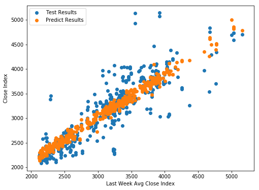

```python
plt.figure(figsize = (8, 6))
plt.scatter(X_test['last_week_ci'], y_test, label = 'Test Results')
plt.scatter(X_test['last_week_ci'], y_preds, label = 'Predict Results');
plt.xlabel('Last Week Avg Close Index')
plt.ylabel('Close Index')
plt.legend();
```